# This is my title - take me out if neccessary

The series of === are just making a line.

I'm reading in the bike lanes here.

```r
# readin is just a 'label' for this code chunk code chunk is just a 'chunk'
# of code, where this code usually does just one thing, aka a module
# comments are still # here you can do all your reading in there
data.dir <- "~/Dropbox/WinterR_2014/Lectures/data"
### let's say we loaded some packages
library(stringr)
library(plyr)
fname <- file.path(data.dir, "Bike_Lanes.csv")
## file.path takes a directory and makes a full name with a full file path
bike = read.csv(fname, as.is = TRUE)
getwd()
```

```
## [1] "/Users/andrew.jaffe/Dropbox/WinterR_2014"
```

You can write your introduction here.

## Introduction

Bike lanes are in Baltimore. People like them. Why are they so long?

## Exploratory Analysis

Let's look at some plots of bike length. Let's say we wanted to look at what affects bike length.

### Plots of bike length

Note we made the subsection by using three "hashes” (pound signs): ###.

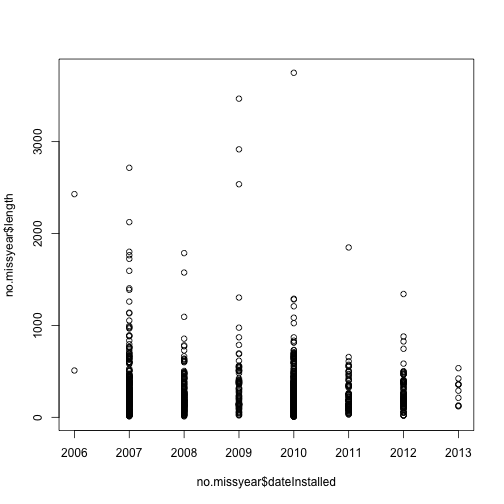

```r
no.missyear <- bike[bike$dateInstalled != 0, ]
plot(no.missyear$dateInstalled, no.missyear$length)
```

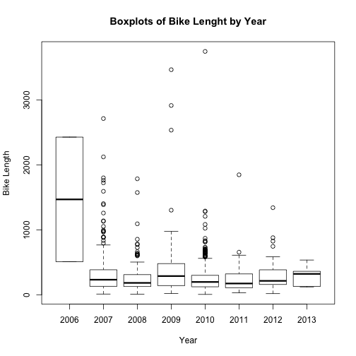

```r
no.missyear$dateInstalled = factor(no.missyear$dateInstalled)
boxplot(no.missyear$length ~ no.missyear$dateInstalled, main = "Boxplots of Bike Lenght by Year",
    xlab = "Year", ylab = "Bike Length")
```

What does it look like if we took the log (base 10) of the bike length:

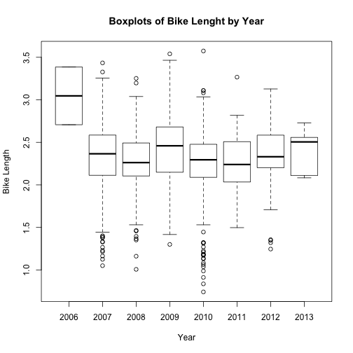

```r
no.missyear$log.length <- log10(no.missyear$length)
### see here that if you specify the data argument, you don't need to do the $
boxplot(log.length ~ dateInstalled, data = no.missyear, main = "Boxplots of Bike Lenght by Year",
    xlab = "Year", ylab = "Bike Length")
```

I want my boxplots colored, so I set the `col` argument.

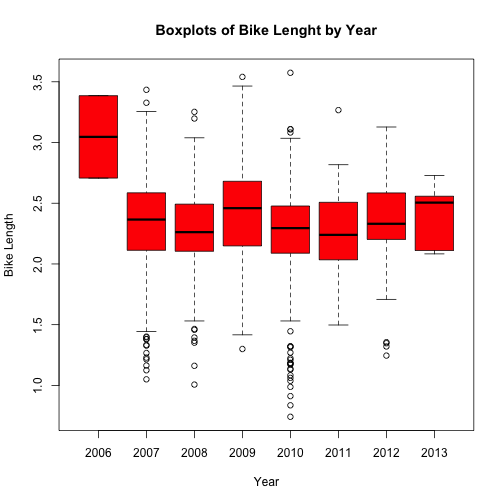

```r
boxplot(log.length ~ dateInstalled, data = no.missyear, main = "Boxplots of Bike Lenght by Year",
    xlab = "Year", ylab = "Bike Length", col = "red")
```

As we can see, 2006 had a much higher bike length. What about for the type of bike path?

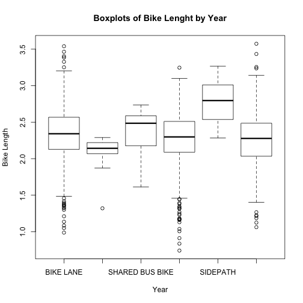

```r
### type is a character, but when R sees a 'character' in a 'formula', then it
### automatically converts it to factor a formula is something that has a y ~
### x, which says I want to plot y against x or if it were a model you would
### do y ~ x, which meant regress against y
boxplot(log.length ~ type, data = no.missyear, main = "Boxplots of Bike Lenght by Year",
    xlab = "Year", ylab = "Bike Length")
```

What if we want to extract means by each type?

Let's show a few ways:

```r
### tapply takes in vector 1, then does a function by vector 2, and then you
### tell what that function is
tapply(no.missyear$log.length, no.missyear$type, mean)
```

```
##       BIKE LANE      CONTRAFLOW SHARED BUS BIKE         SHARROW
##           2.331           2.087           2.363           2.256
##        SIDEPATH    SIGNED ROUTE
##           2.782           2.264
```

```r
## aggregate
aggregate(x = no.missyear$log.length, by = list(no.missyear$type), FUN = mean)
```

```
##           Group.1     x
## 1       BIKE LANE 2.331
## 2      CONTRAFLOW 2.087
## 3 SHARED BUS BIKE 2.363
## 4         SHARROW 2.256
## 5        SIDEPATH 2.782
## 6    SIGNED ROUTE 2.264
```

```r
### now let's specify the data argument and use a 'formula' - much easier to
### read and more 'intuitive'
aggregate(log.length ~ type, data = no.missyear, FUN = mean)
```

```
##              type log.length
## 1       BIKE LANE      2.331
## 2      CONTRAFLOW      2.087
## 3 SHARED BUS BIKE      2.363
## 4         SHARROW      2.256
## 5        SIDEPATH      2.782
## 6    SIGNED ROUTE      2.264
```

```r
## ddply is from the plyr package takes in a data frame, (the first d refers
## to data.frame) splits it up by some variables (let's say type) then we'll
## use summarise to summarize whatever we want then returns a data.frame (the
## second d) - hence why it's ddply if we wanted to do it on a 'list' thne
## return data.frame, it'd be ldply
ddply(no.missyear, .(type), summarise, mean = mean(log.length))
```

```
##              type  mean
## 1       BIKE LANE 2.331
## 2      CONTRAFLOW 2.087
## 3 SHARED BUS BIKE 2.363
## 4         SHARROW 2.256
## 5        SIDEPATH 2.782
## 6    SIGNED ROUTE 2.264
```

`ddply` (and other functions in the `plyr` package) is cool because you can do multiple functions really easy.

Let's show a what if we wanted to go over `type` and `dateInstalled`:

```r
### For going over 2 variables, we need to do it over a 'list' of vectors
tapply(no.missyear$log.length, list(no.missyear$type, no.missyear$dateInstalled),
    mean)
```

```
##                  2006  2007  2008  2009  2010  2011  2012  2013
## BIKE LANE       3.046 2.351 2.366 2.381 2.307 2.242 2.362 2.408
## CONTRAFLOW         NA    NA    NA    NA 2.087    NA    NA    NA
## SHARED BUS BIKE    NA    NA    NA 2.351 2.404    NA    NA    NA
## SHARROW            NA 2.301 2.221 2.692 2.247    NA 2.236    NA
## SIDEPATH           NA    NA 2.625    NA 2.774 3.267    NA    NA
## SIGNED ROUTE       NA 2.288    NA    NA 2.239 2.210    NA    NA
```

```r
tapply(no.missyear$log.length, list(no.missyear$type, no.missyear$dateInstalled),
    mean, na.rm = TRUE)
```

```
##                  2006  2007  2008  2009  2010  2011  2012  2013
## BIKE LANE       3.046 2.351 2.366 2.381 2.307 2.242 2.362 2.408
## CONTRAFLOW         NA    NA    NA    NA 2.087    NA    NA    NA
## SHARED BUS BIKE    NA    NA    NA 2.351 2.404    NA    NA    NA
## SHARROW            NA 2.301 2.221 2.692 2.247    NA 2.236    NA
## SIDEPATH           NA    NA 2.625    NA 2.774 3.267    NA    NA
## SIGNED ROUTE       NA 2.288    NA    NA 2.239 2.210    NA    NA
```

```r
## aggregate - looks better
aggregate(log.length ~ type + dateInstalled, data = no.missyear, FUN = mean)
```

```
##               type dateInstalled log.length
## 1        BIKE LANE          2006      3.046
## 2        BIKE LANE          2007      2.351
## 3          SHARROW          2007      2.301
## 4     SIGNED ROUTE          2007      2.288
## 5        BIKE LANE          2008      2.366
## 6          SHARROW          2008      2.221
## 7         SIDEPATH          2008      2.625
## 8        BIKE LANE          2009      2.381
## 9  SHARED BUS BIKE          2009      2.351
## 10         SHARROW          2009      2.692
## 11       BIKE LANE          2010      2.307
## 12      CONTRAFLOW          2010      2.087
## 13 SHARED BUS BIKE          2010      2.404
## 14         SHARROW          2010      2.247
## 15        SIDEPATH          2010      2.774
## 16    SIGNED ROUTE          2010      2.239
## 17       BIKE LANE          2011      2.242
## 18        SIDEPATH          2011      3.267
## 19    SIGNED ROUTE          2011      2.210
## 20       BIKE LANE          2012      2.362
## 21         SHARROW          2012      2.236
## 22       BIKE LANE          2013      2.408
```

```r
## ddply is from the plyr package
ddply(no.missyear, .(type, dateInstalled), summarise, mean = mean(log.length),
    median = median(log.length), Mode = mode(log.length), Std.Dev = sd(log.length))
```

```
##               type dateInstalled  mean median    Mode Std.Dev
## 1        BIKE LANE          2006 3.046  3.046 numeric 0.47974
## 2        BIKE LANE          2007 2.351  2.444 numeric 0.40662
## 3        BIKE LANE          2008 2.366  2.355 numeric 0.38916
## 4        BIKE LANE          2009 2.381  2.311 numeric 0.49447
## 5        BIKE LANE          2010 2.307  2.328 numeric 0.32076
## 6        BIKE LANE          2011 2.242  2.235 numeric 0.33398
## 7        BIKE LANE          2012 2.362  2.324 numeric 0.28528
## 8        BIKE LANE          2013 2.408  2.505 numeric 0.24041
## 9       CONTRAFLOW          2010 2.087  2.142 numeric 0.25655
## 10 SHARED BUS BIKE          2009 2.351  2.464 numeric 0.30610
## 11 SHARED BUS BIKE          2010 2.404  2.587 numeric 0.27380
## 12         SHARROW          2007 2.301  2.364 numeric 0.42193
## 13         SHARROW          2008 2.221  2.238 numeric 0.32664
## 14         SHARROW          2009 2.692  2.708 numeric 0.06945
## 15         SHARROW          2010 2.247  2.298 numeric 0.35905
## 16         SHARROW          2012 2.236  2.339 numeric 0.42924
## 17        SIDEPATH          2008 2.625  2.787 numeric 0.29583
## 18        SIDEPATH          2010 2.774  2.774 numeric 0.33480
## 19        SIDEPATH          2011 3.267  3.267 numeric      NA
## 20    SIGNED ROUTE          2007 2.288  2.332 numeric 0.41825
## 21    SIGNED ROUTE          2010 2.239  2.256 numeric 0.39201
## 22    SIGNED ROUTE          2011 2.210  2.208 numeric 0.20880
```

OK let's do an linear model

```r
### type is a character, but when R sees a 'character' in a 'formula', then it
### automatically converts it to factor a formula is something that has a y ~
### x, which says I want to plot y against x or if it were a model you would
### do y ~ x, which meant regress against y
mod.type = lm(log.length ~ type, data = no.missyear)
mod.yr = lm(log.length ~ factor(dateInstalled), data = no.missyear)
mod.yrtype = lm(log.length ~ type + factor(dateInstalled), data = no.missyear)
summary(mod.type)
```

```
##
## Call:
## lm(formula = log.length ~ type, data = no.missyear)
##
## Residuals:
##     Min      1Q  Median      3Q     Max
## -1.5150 -0.1906  0.0292  0.2322  1.3102
##
## Coefficients:
##                     Estimate Std. Error t value Pr(>|t|)
## (Intercept)           2.3306     0.0149  156.70  < 2e-16 ***
## typeCONTRAFLOW       -0.2434     0.1029   -2.37  0.01813 *
## typeSHARED BUS BIKE   0.0324     0.0606    0.53  0.59319
## typeSHARROW          -0.0742     0.0213   -3.48  0.00051 ***
## typeSIDEPATH          0.4512     0.1506    3.00  0.00277 **
## typeSIGNED ROUTE     -0.0669     0.0273   -2.45  0.01430 *
## ---
## Signif. codes:  0 '***' 0.001 '**' 0.01 '*' 0.05 '.' 0.1 ' ' 1
##
## Residual standard error: 0.367 on 1499 degrees of freedom
## Multiple R-squared:  0.0196, Adjusted R-squared:  0.0163
## F-statistic: 5.98 on 5 and 1499 DF,  p-value: 1.74e-05
```

That's rather UGLY, so let's use a package called `xtable` and then make this model into an `xtable` object and then print it out nicely.

```r
### DON'T DO THIS.  YOU SHOULD ALWAYS DO library() statements in the FIRST
### code chunk.  this is just to show you the logic of a report/analysis.
require(xtable)
# smod <- summary(mod.yr)
xtab <- xtable(mod.yr)
```

Well `xtable` can make html tables, so let's print this. We must tell R that the results is actually an html output, so we say the results should be embedded in the html “asis” (aka just print out whatever R spits out).

```r
print.xtable(xtab, type = "html")
```

|  | Estimate | Std. Error | t value | Pr(> \|t\|) |
| --- | --- | --- | --- | --- |
| (Intercept) | 3.0463 | 0.2600 | 11.71 | 0.0000 |
| factor(dateInstalled)2007 | -0.7332 | 0.2608 | -2.81 | 0.0050 |
| factor(dateInstalled)2008 | -0.7808 | 0.2613 | -2.99 | 0.0029 |
| factor(dateInstalled)2009 | -0.6394 | 0.2631 | -2.43 | 0.0152 |
| factor(dateInstalled)2010 | -0.7791 | 0.2605 | -2.99 | 0.0028 |
| factor(dateInstalled)2011 | -0.8022 | 0.2626 | -3.05 | 0.0023 |
| factor(dateInstalled)2012 | -0.7152 | 0.2625 | -2.72 | 0.0065 |
| factor(dateInstalled)2013 | -0.6380 | 0.2849 | -2.24 | 0.0253 |

OK, that's pretty good, but let's say we have all three models. Another package called `stargazer` can put models together easily and pritn them out. So `xtable` is really good when you are trying to print out a table (in html, otherwise make the table and use `write.csv` to get it in Excel and then format) really quickly and in a report. But it doesn't work so well with *many* models together. So let's use stargazer. Again, you need to use `install.packages("stargazer")` if you don't have function.

```r
require(stargazer)
```

```r
stargazer(mod.yr, mod.type, mod.yrtype, type = "text")
```

```
Error: could not find function "stargazer"
```

## Data Extraction

```r
### let's get number of bike lanes installed by year
n.lanes = ddply(no.missyear, .(dateInstalled), nrow)
names(n.lanes) <- c("date", "nlanes")
n2009 <- n.lanes$nlanes[n.lanes$date == 2009]
n2010 <- n.lanes$nlanes[n.lanes$date == 2010]
getwd()
```

```
## [1] "/Users/andrew.jaffe/Dropbox/WinterR_2014"
```

Now I can just say there are 86 lanes in 2009 and 625 in 2010.

```r
fname <- file.path(data.dir, "Charm_City_Circulator_Ridership.csv")
## file.path takes a directory and makes a full name with a full file path
charm = read.csv(fname, as.is = TRUE)

library(chron)
```

```
## Error: there is no package called 'chron'
```

```r
days = levels(weekdays(1, abbreviate = FALSE))
```

```
## Error: no applicable method for 'weekdays' applied to an object of class
## "c('double', 'numeric')"
```

```r
charm$day <- factor(charm$day, levels = days)
```

```
## Error: object 'days' not found
```

```r
charm$date <- as.Date(charm$date, format = "%m/%d/%Y")
cn <- colnames(charm)
daily <- charm[, c("day", "date", "daily")]
```

```r
charm$daily <- NULL
require(reshape2)
long.charm <- melt(charm, id.vars = c("day", "date"))
long.charm$type <- "Boardings"
long.charm$type[grepl("Alightings", long.charm$variable)] <- "Alightings"
long.charm$type[grepl("Average", long.charm$variable)] <- "Average"

long.charm$line <- "orange"
long.charm$line[grepl("purple", long.charm$variable)] <- "purple"
long.charm$line[grepl("green", long.charm$variable)] <- "green"
long.charm$line[grepl("banner", long.charm$variable)] <- "banner"
long.charm$variable <- NULL

long.charm$line <- factor(long.charm$line, levels = c("orange", "purple", "green",
    "banner"))

head(long.charm)
```

```
##         day       date value      type   line
## 1    Monday 2010-01-11   877 Boardings orange
## 2   Tuesday 2010-01-12   777 Boardings orange
## 3 Wednesday 2010-01-13  1203 Boardings orange
## 4  Thursday 2010-01-14  1194 Boardings orange
## 5    Friday 2010-01-15  1645 Boardings orange
## 6  Saturday 2010-01-16  1457 Boardings orange
```

```r
### NOW R has a column of day, the date, a 'value', the type of value and the
### circulator line that corresponds to it value is now either the Alightings,
### Boardings, or Average from the charm dataset
```

Let's do some plotting now!

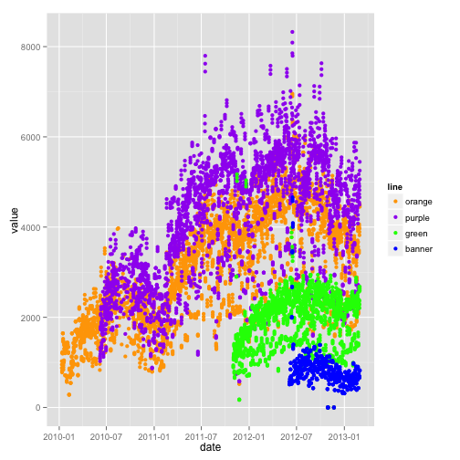

```r
require(ggplot2)
### let's make a 'ggplot' the format is ggplot(dataframe, aes(x=COLNAME,
### y=COLNAME)) where COLNAME are colnames of the dataframe you can also set
### color to a different factor other options in AES (fill, alpha level -which
### is the 'transparency' of points)
g <- ggplot(long.charm, aes(x = date, y = value, color = line))
### let's change the colors to what we want- doing this manually, not letting
### it choose for me
g <- g + scale_color_manual(values = c("orange", "purple", "green", "blue"))
### plotting points
g + geom_point()
```

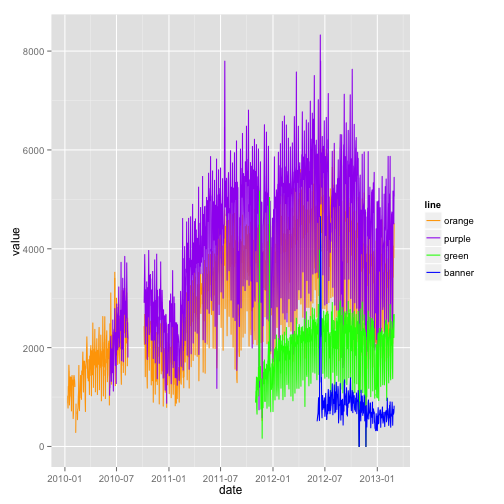

```r
### Let's make Lines!
g + geom_line()
```

```
## Warning: Removed 1814 rows containing missing values (geom_point).
## Warning: Removed 1700 rows containing missing values (geom_point).
## Warning: Removed 1814 rows containing missing values (geom_point).
```

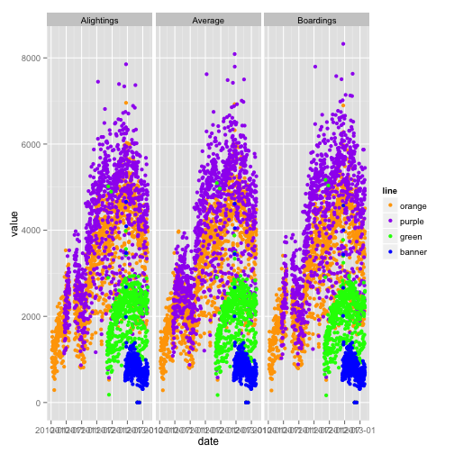

```r
### let's make a new plot of poitns
gpoint <- g + geom_point()
### let's plot the value by the type of value - boardings/average, etc
gpoint + facet_wrap(~type)
```

OK let's turn off some warnings - making `warning=FALSE` as an option.

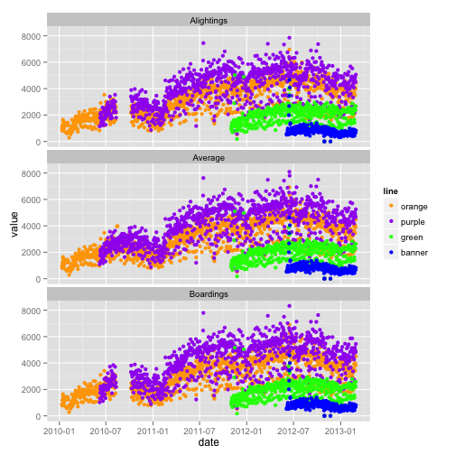

```r
## let's compare vertically
gpoint + facet_wrap(~type, ncol = 1)
```

[output not shown]

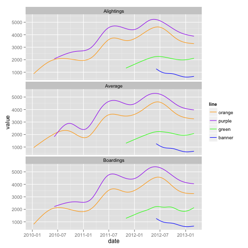

```r
gfacet = g + facet_wrap(~type, ncol = 1)
## let's smooth this - get a rough estimate of what's going on
gfacet + geom_smooth(se = FALSE)
```

OK, I've seen enough code, let's turn that off, using `echo=FALSE`.

[output not shown]

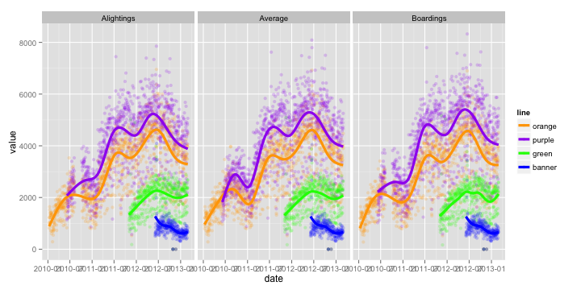